# Data Viz and Regression in R

Aaron R. Williams

This guide is a brief introduction to code for implementing and visually evaluating linear regression models in R. It does not address the theory behind linear regression models.

# `lm()`

Linear regression models like OLS regression are estimated in R with `lm()`. Here is a simple OLS model with stopping distance as the dependent variable and speed as the independent variable.

```r
lm(formula = dist ~ speed, data = cars)
```

```
##
## Call:
## lm(formula = dist ~ speed, data = cars)
##
## Coefficients:
## (Intercept)        speed
##     -17.579        3.932
```

# The lm object

The `lm()` function creates an object of class `"lm"`. Many R functions have convenient methods for this object that are useful for understanding and using the output of a regression model.

```r
# sample 1,000 observations and set ordinal factors to nominal
set.seed(20200622)

diamonds <- diamonds %>%
  sample_n(1000) %>%
  mutate(across(where(is.factor), .fns = as.character))
```

```r
# estimate a multiple linear regression model
diamonds_model1 <- lm(formula = price ~ carat + cut, data = diamonds)

class(diamonds_model1)
```

```
## [1] "lm"
```

## Summary

`summary()` returns a regression table with the call, a five number summary of the residuals, coefficient estimates, standard errors, t statistics, p-values, the residual standard error, $R^2$, adjusted $R ^ 2$, the F-statistic, and the p-value for the F-statistic.

```r
summary(diamonds_model1)
```

```
##
## Call:
## lm(formula = price ~ carat + cut, data = diamonds)
##
## Residuals:
##     Min      1Q  Median      3Q     Max
## -4748.7  -746.3   -58.8   552.0  8372.5
##
## Coefficients:
##              Estimate Std. Error t value             Pr(>|t|)
## (Intercept)  -3917.21     249.55 -15.697 < 0.0000000000000002 ***
## carat         8084.83      97.81  82.658 < 0.0000000000000002 ***
## cutGood       1024.25     282.24   3.629             0.000299 ***
## cutIdeal      1801.23     242.54   7.427    0.000000000000239 ***
## cutPremium    1272.62     247.66   5.139    0.000000333191249 ***
## cutVery Good  1331.89     250.24   5.322    0.000000126570004 ***
## ---
## Signif. codes:  0 '***' 0.001 '**' 0.01 '*' 0.05 '.' 0.1 ' ' 1
##
## Residual standard error: 1454 on 994 degrees of freedom
## Multiple R-squared:  0.8742, Adjusted R-squared:  0.8736
## F-statistic:  1381 on 5 and 994 DF,  p-value: < 0.00000000000000022
```

## Coefficients

`coef()` can be used to select just the coefficients:

```r
coef(diamonds_model1)
```

```
##  (Intercept)        carat      cutGood     cutIdeal   cutPremium cutVery Good
##    -3917.206     8084.834     1024.253     1801.234     1272.617     1331.893
```

## Residuals

`resid()` can used to select just a vector of the residuals.

```r
resid(diamonds_model1)[1:10]
```

```
##           1           2           3           4           5           6
##  -561.07154 -2590.97665    30.67304   -84.26074  1569.36440 -1208.86273
##           7           8           9          10
##   334.17038    73.83931  -660.82982  -243.98049
```

## Diagnostic plots

`plot()` will return four plots with regression diagnostics.

- **(1) Residual plot:** This demonstrates if the residuals have non-linear patterns or non-constant variance.
- **(2) Normal QQ plot:** This demonstrates if the residuals are normally distributed.
- **(3) Scale-Location plot:** This also demonstrates if the residuals have non-constant variance.
- **(4): Residuals vs. leverage plot** This demonstrates cases that may be influential.

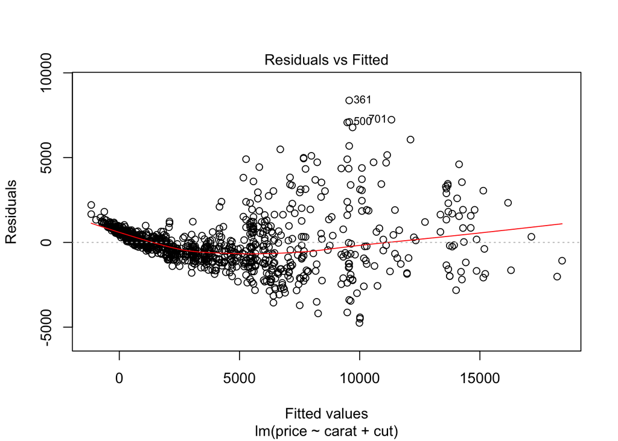

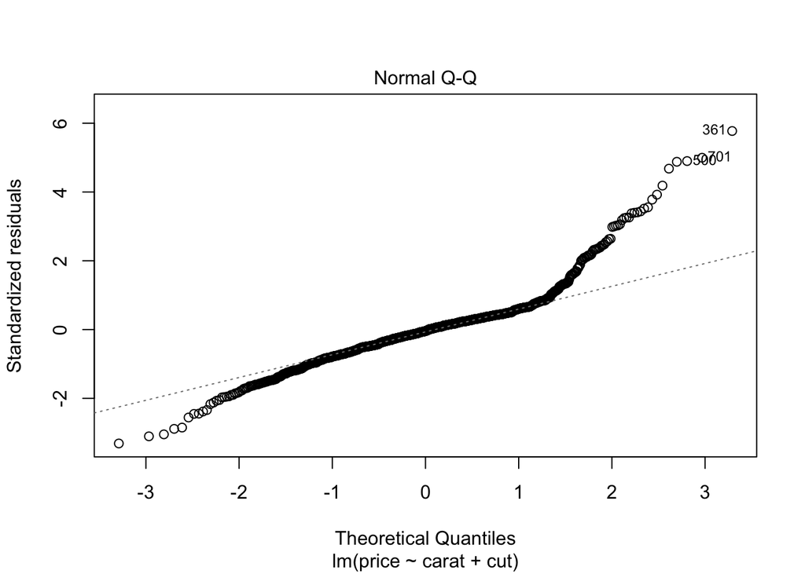

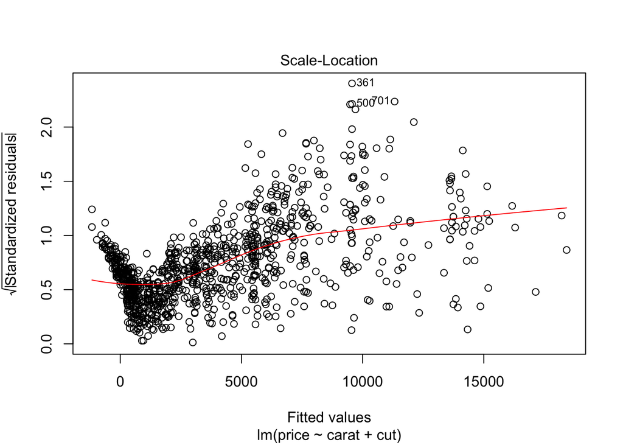

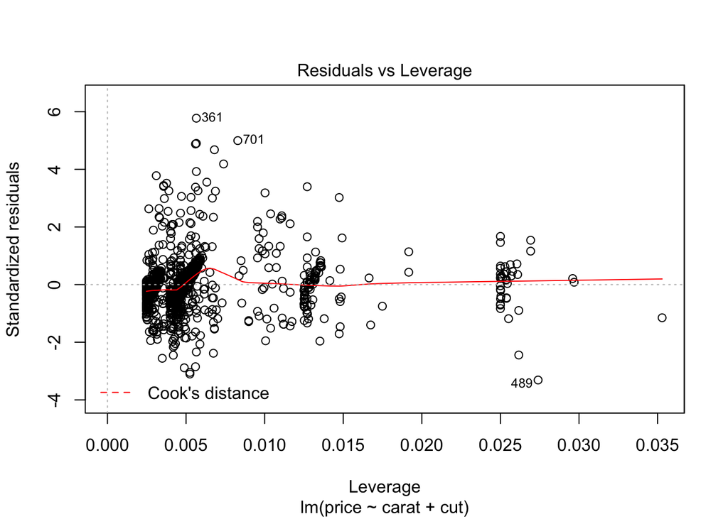

```r
plot(diamonds_model1)
```

# `library(modelr)`

`library(modelr)` has many useful functions for modeling. It works with more types of models than just linear models from `lm()`.

## `add_predictions()`

`add_predictions()` adds predictions to a data set using an estimated model object.

```r
add_predictions(data = diamonds, model = diamonds_model1)
```

```
## # A tibble: 1,000 x 11
##    carat cut       color clarity depth table price     x     y     z   pred
##    <dbl> <chr>     <chr> <chr>   <dbl> <dbl> <int> <dbl> <dbl> <dbl>  <dbl>
##  1  0.7  Very Good I     VVS1     62.9    58  2513  5.65  5.67  3.56  3074.
##  2  1.52 Ideal     I     SI2      61.7    57  7582  7.38  7.41  4.56 10173.
##  3  0.31 Ideal     H     SI1      61.3    55   421  4.35  4.39  2.68   390.
##  4  0.71 Ideal     D     VS2      59.9    57  3540  5.8   5.83  3.48  3624.
##  5  2.07 Ideal     I     SI2      62      55 16189  8.12  8.22  5.07 14620.
##  6  1    Ideal     E     SI2      61.9    56  4760  6.43  6.4   3.97  5969.
##  7  1.2  Ideal     G     SI1      61.2    56  7920  6.87  6.88  4.21  7586.
##  8  0.52 Good      H     VS2      63.7    54  1385  5.12  5.09  3.25  1311.
##  9  0.65 Very Good G     VS2      63.2    57  2009  5.54  5.47  3.48  2670.
## 10  0.49 Premium   F     SI2      62.2    59  1073  5.09  5.04  3.15  1317.
## # … with 990 more rows
```

## `add_residuals()`

`add_residuals()` adds residuals to a data set using an estimated model object.

```r
add_residuals(data = diamonds, model = diamonds_model1)
```

```
## # A tibble: 1,000 x 11
##    carat cut       color clarity depth table price     x     y     z   resid
##    <dbl> <chr>     <chr> <chr>   <dbl> <dbl> <int> <dbl> <dbl> <dbl>   <dbl>
##  1  0.7  Very Good I     VVS1     62.9    58  2513  5.65  5.67  3.56  -561.
##  2  1.52 Ideal     I     SI2      61.7    57  7582  7.38  7.41  4.56 -2591.
##  3  0.31 Ideal     H     SI1      61.3    55   421  4.35  4.39  2.68    30.7
##  4  0.71 Ideal     D     VS2      59.9    57  3540  5.8   5.83  3.48   -84.3
##  5  2.07 Ideal     I     SI2      62      55 16189  8.12  8.22  5.07  1569.
##  6  1    Ideal     E     SI2      61.9    56  4760  6.43  6.4   3.97 -1209.
##  7  1.2  Ideal     G     SI1      61.2    56  7920  6.87  6.88  4.21   334.
##  8  0.52 Good      H     VS2      63.7    54  1385  5.12  5.09  3.25    73.8
##  9  0.65 Very Good G     VS2      63.2    57  2009  5.54  5.47  3.48  -661.
## 10  0.49 Premium   F     SI2      62.2    59  1073  5.09  5.04  3.15  -244.
## # … with 990 more rows
```

## `data_grid()`

`data_grid()` creates an evenly-spaced grid of points using the range of observed predictors in a data set. This is useful for visualization and is really, really useful for understanding generalized linear models.

```r
data_grid(data = diamonds, carat, cut) %>%
  add_predictions(diamonds_model1)
```

```
## # A tibble: 765 x 3
##    carat cut         pred
##    <dbl> <chr>      <dbl>
##  1  0.2  Fair      -2300.
##  2  0.2  Good      -1276.
##  3  0.2  Ideal      -499.
##  4  0.2  Premium   -1028.
##  5  0.2  Very Good  -968.
##  6  0.23 Fair      -2058.
##  7  0.23 Good      -1033.
##  8  0.23 Ideal      -256.
##  9  0.23 Premium    -785.
## 10  0.23 Very Good  -726.
## # … with 755 more rows
```

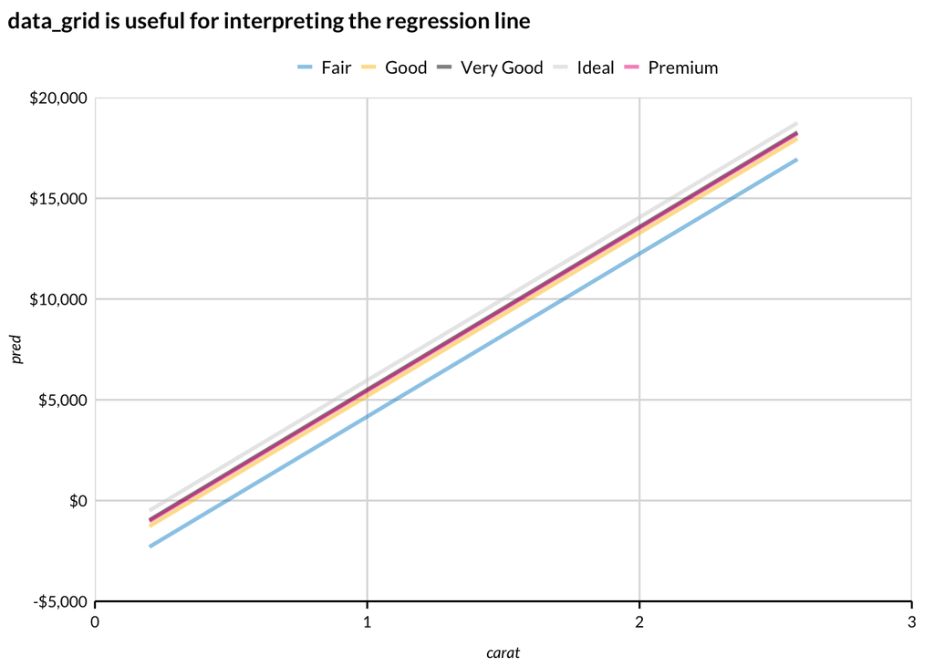

# `library(broom)`

`library(broom)` contains three helpful functions for tidying the output of estimated models. It has methods for many types of models. We will demonstrate applications with `lm()`.

Estimated regression functions have diagnostics at the model level, at the coefficient level, and at the observation level.

## `glance()`

`glance()` returns model-level diagnostics like $R^2$ and $\hat{\sigma}$.

```r
glance(diamonds_model1)
```

```
## # A tibble: 1 x 12
##   r.squared adj.r.squared sigma statistic p.value    df logLik    AIC    BIC
##       <dbl>         <dbl> <dbl>     <dbl>   <dbl> <dbl>  <dbl>  <dbl>  <dbl>
## 1     0.874         0.874 1454.     1381.       0     5 -8698. 17410. 17445.
## # … with 3 more variables: deviance <dbl>, df.residual <int>, nobs <int>
```

## `tidy()`

`tidy()` returns coefficient-level diagnostics like standard errors and p-values.

```r
tidy(diamonds_model1)
```

```
## # A tibble: 6 x 5
##   term         estimate std.error statistic  p.value
##   <chr>           <dbl>     <dbl>     <dbl>    <dbl>
## 1 (Intercept)    -3917.     250.     -15.7  9.01e-50
## 2 carat           8085.      97.8     82.7  0
## 3 cutGood         1024.     282.       3.63 2.99e- 4
## 4 cutIdeal        1801.     243.       7.43 2.39e-13
## 5 cutPremium      1273.     248.       5.14 3.33e- 7
## 6 cutVery Good    1332.     250.       5.32 1.27e- 7
```

## `augment()`

`augment()` returns observation-level diagnostics like residuals and hat values.

```r
augment(diamonds_model1)
```

```
## # A tibble: 1,000 x 9
##    price carat cut       .fitted  .resid    .hat .sigma     .cooksd .std.resid
##    <int> <dbl> <chr>       <dbl>   <dbl>   <dbl>  <dbl>       <dbl>      <dbl>
##  1  2513  0.7  Very Good   3074.  -561.  0.00449  1455. 0.000112       -0.387
##  2  7582  1.52 Ideal      10173. -2591.  0.00539  1453. 0.00288        -1.79
##  3   421  0.31 Ideal        390.    30.7 0.00324  1455. 0.000000242     0.0211
##  4  3540  0.71 Ideal       3624.   -84.3 0.00248  1455. 0.00000140     -0.0580
##  5 16189  2.07 Ideal      14620.  1569.  0.0107   1454. 0.00213         1.09
##  6  4760  1    Ideal       5969. -1209.  0.00284  1454. 0.000329       -0.833
##  7  7920  1.2  Ideal       7586.   334.  0.00353  1455. 0.0000313       0.230
##  8  1385  0.52 Good        1311.    73.8 0.0128   1455. 0.00000566      0.0511
##  9  2009  0.65 Very Good   2670.  -661.  0.00454  1455. 0.000158       -0.455
## 10  1073  0.49 Premium     1317.  -244.  0.00473  1455. 0.0000224      -0.168
## # … with 990 more rows
```

# Data viz

`library(broom)` is incredibly helpful for data visualization.

## Coefficient plot

Here’s a simple plot of estimated OLS coefficients and their 95% confidence intervals.

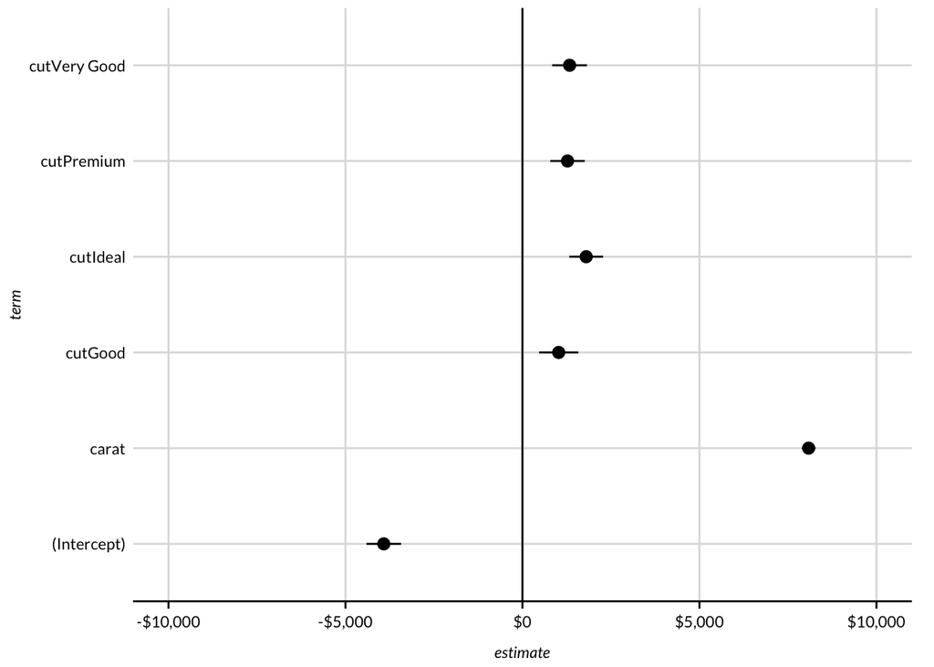

```r
tidy(diamonds_model1,
     conf.int = TRUE,
     conf.level = 0.95) %>%
  ggplot(aes(x = estimate,
             y = term,
             xmin = conf.low,
             xmax = conf.high)) +
  geom_pointrange() +
  geom_vline(xintercept = 0) +
  scale_x_continuous(limits = c(-10000, 10000),
                     labels = scales::dollar) +
  scatter_grid() +
  labs()
```

## Residual plot

Here’s an even simpler residual plot. The non-constant errors are a big issue and our specification is clearly inadequate!

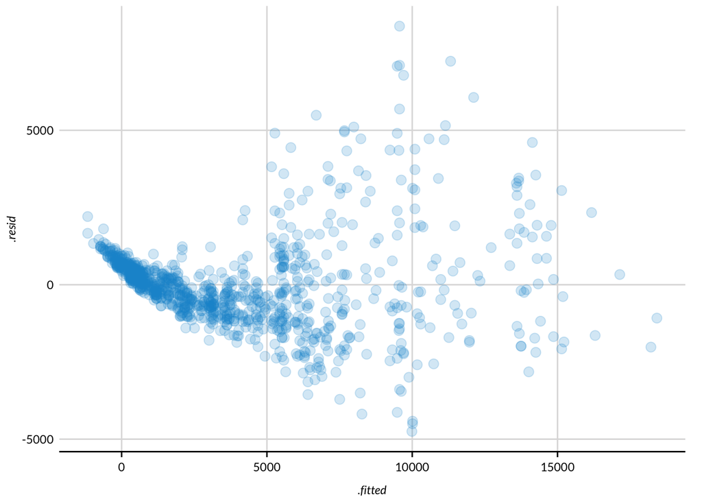

```r
augment(diamonds_model1) %>%
  ggplot(aes(.fitted, .resid)) +
  geom_point(alpha = 0.2) +
  scatter_grid()
```

## Many models

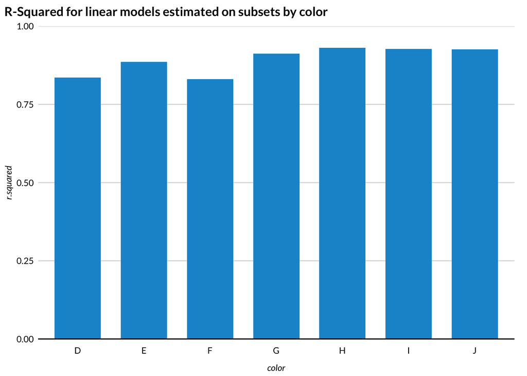

```r
# estimate a linear model for each of seven colors
many_models <- diamonds %>%
  split(diamonds$color) %>%
  map(~lm(formula = price ~ carat + cut, data = .))

# extract model diagnostics from each model
many_models_results <- bind_cols(
  color = names(many_models),
  map_df(many_models, glance)
)

# plot
many_models_results %>%
  ggplot(aes(color, r.squared)) +
  geom_col() +
  scale_y_continuous(expand = c(0, 0),
                     limits = c(0, 1)) +
  labs(title = "R-Squared for linear models estimated on subsets by color") +
  remove_ticks()
```

[Hadley Wickham gave a great talk about this to the The Edinburgh R User Group.](https://www.youtube.com/watch?v=rz3_FDVt9eg)

### Exercise 1

Step 1: Pick a data set. It could be your own or it could be from `data()`. Basic options include `msleep` and `mpg`.

Step 2: Estimate a simple or multiple linear regression with `lm()`. The model does not need to be great.

Step 3: Use `library(broom)` and create a visualization that includes the coefficients.

Step 4: Use `library(broom)` and create a visualization that includes data at the observation level (i.e. residuals, predicted values, etc.).